# *Scatterplot Matrix* & Correlograma

#### Controle da escala de cores:

Por default, a função `ggcorr()` usa uma escala de cores contínua, no intervalo de -1 a 1 para mostrar a força das correlações representadas na matriz. Para mudar para cores categóricas, o usuário tem de acrescentar o argumento `nbreaks`, que especifica quantas classes a escala de cores deveria ter:

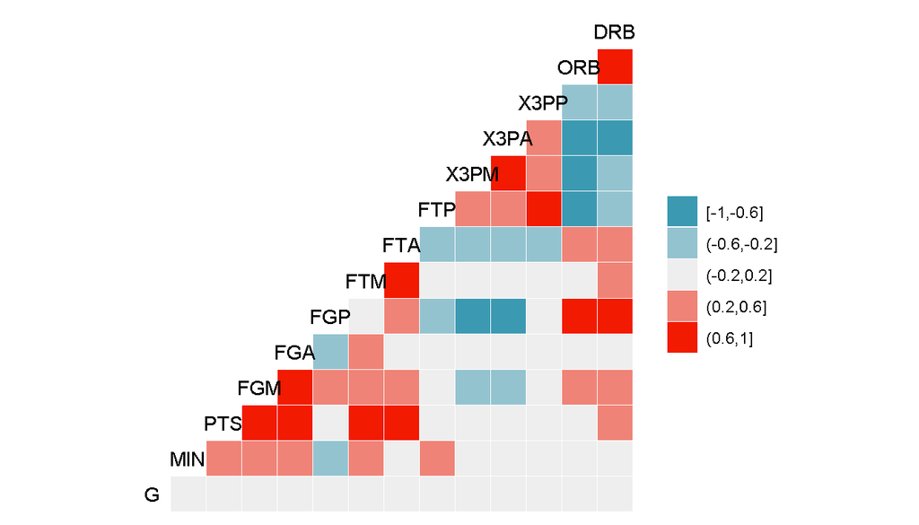

```r
       # ----- Controle escala de cores  -------
ggcorr(nba[, 1:14], nbreaks = 5)
```

Quando o argumento `nbreaks` é usado, o número de dígitos mostrado na escala de cores é controlado pelo argumento `digits`. O default é `digits = 2`, mas ele será um único dígito se as classes não exegirem mais precisão.

O argumento `name` exerce controle adicional sobre a escala de cores, definindo seu nome; o argumento `legend.size`, que define o tamanho do texto da legenda, e o argumento `legend.position`, que controla onde a legenda será exibida. Os dois últimos são apenas atalhos para os mesmos argumentos no tema do `ggplot2`. Como o gráfico é um objeto `ggplot2`, todos os outros métodos relevantes também se aplicam:

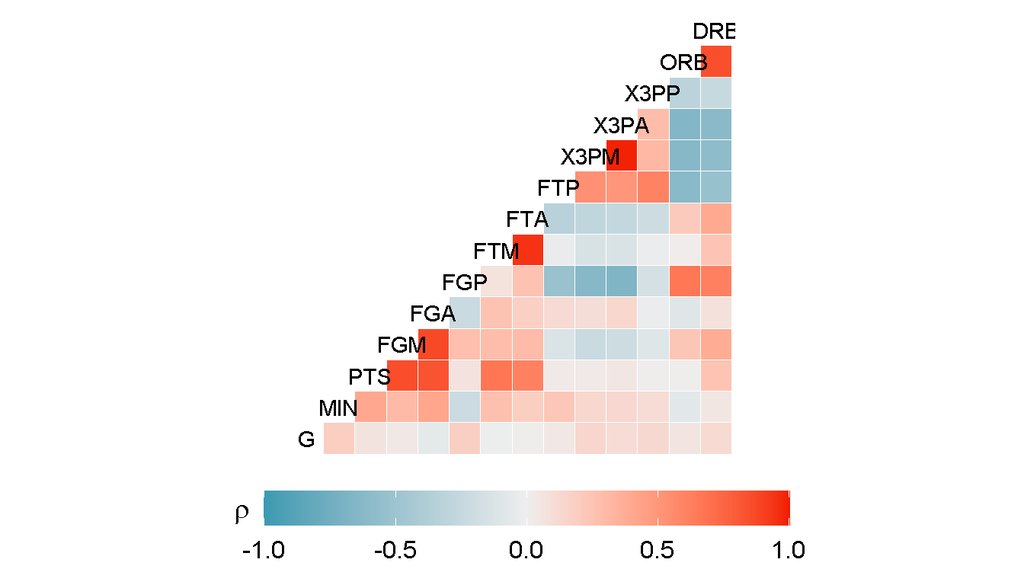

```r
  # controle legenda
ggcorr(nba[, 1:14], name = expression(rho), legend.position = "bottom",
       legend.size = 12) +
  guides(fill = guide_colorbar(barwidth = 18, title.vjust = 0.75)) +
  theme(legend.title = element_text(size = 14))
```

#### Controle da palheta de cores:

A função `ggcorr()` usa o gradiente default de cores, que vai do vermelho brilhante ao cinza claro ao azul brilhante. Esse gradiente pode ser modificado pelos argumentos `low`, `mid` e `high`, que são semelhantes àqueles do argumento `scale_gradient2` no `ggplot2`:

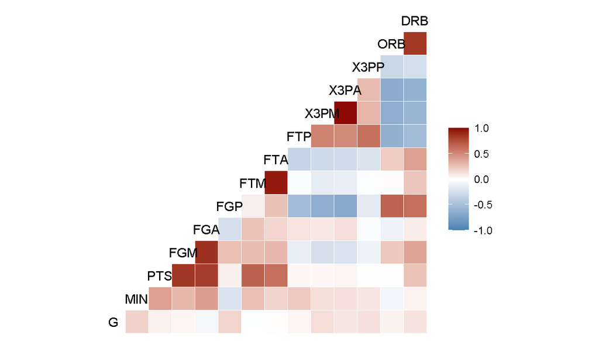

```r
 # mudança gradiente de cores
ggcorr(nba[, 1:14], low = "steelblue", mid = "white", high = "darkred")
```

Por dafaul, o ponto central da escala de cores é ajustado para $0$, indicando correlação nula. O argumento `midpoint`pode ser usado para modificar esse ajuste. Em particular, para `midpoint = NULL` será selecionado automaticamente o coeficinte de correlação mediano como o ponto central da escala, mostrando no console esse valor:

```r
  # centro da escala no coeficiente median
ggcorr(nba[, 1:14], midpoint = NULL)
```

```
## Color gradient midpoint set at median correlation to 0.08
```

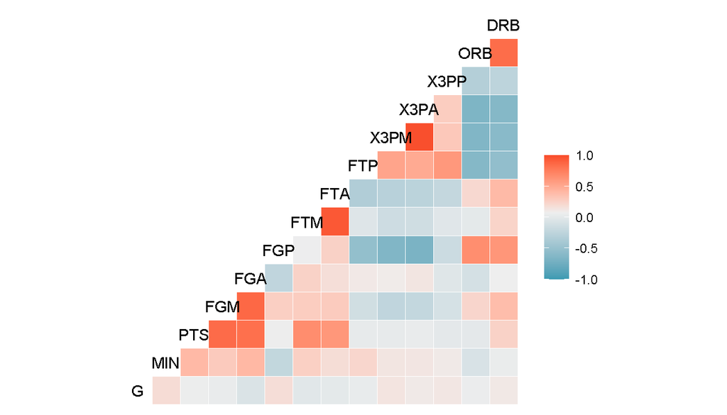

Uma outra alternativa para controlar a escala de cores é usar uma palheta `ColorBrewer` no argumento `palette`. Esse argumento deveria ser usado somente quando a escala de cores for categórica, isto é, quando o argumento `nbreaks` estiver sendo usado.

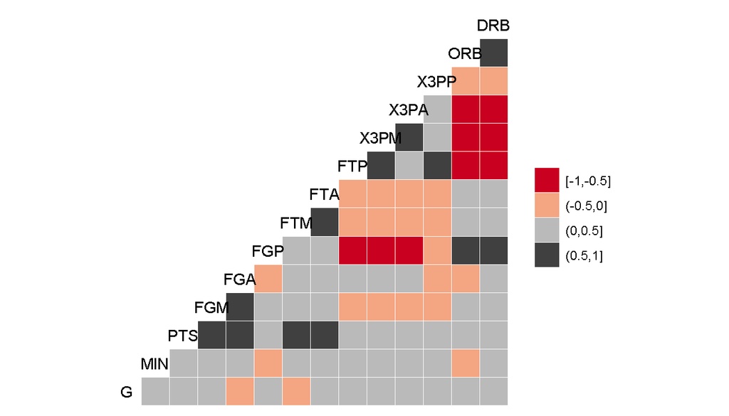

```r
ggcorr(nba[, 1:14], nbreaks = 4, palette = "RdGy")
```

#### Controle da geometria principal;

Por default, a função `ggcorr()` ele usa quadriculados coloridos para representar a força dos coeficientes de correlação, similar à maneira como os mapas de calor representam contagens de observações. As correlações podem ser representadas por círculos com tamanhos proporcionais a seus valores, ajustando seu argumeno `geom`para `circle`.

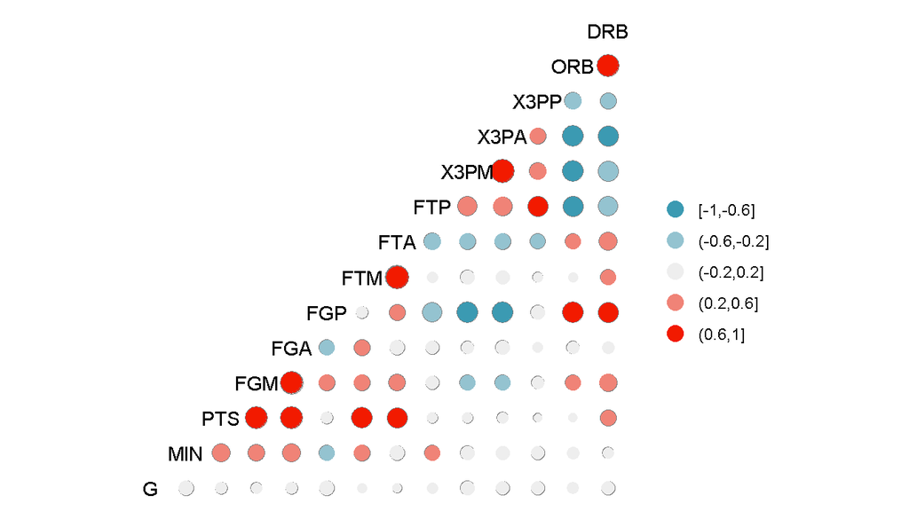

```r
  # mudança na geomentria principal
ggcorr(nba[, 1:14], geom = "circle", nbreaks = 5)
```

Pode-se também ajustar os tamanhos mínimo e máximo dos círculos por meio dos argumentos `min_size` e `max_size`:

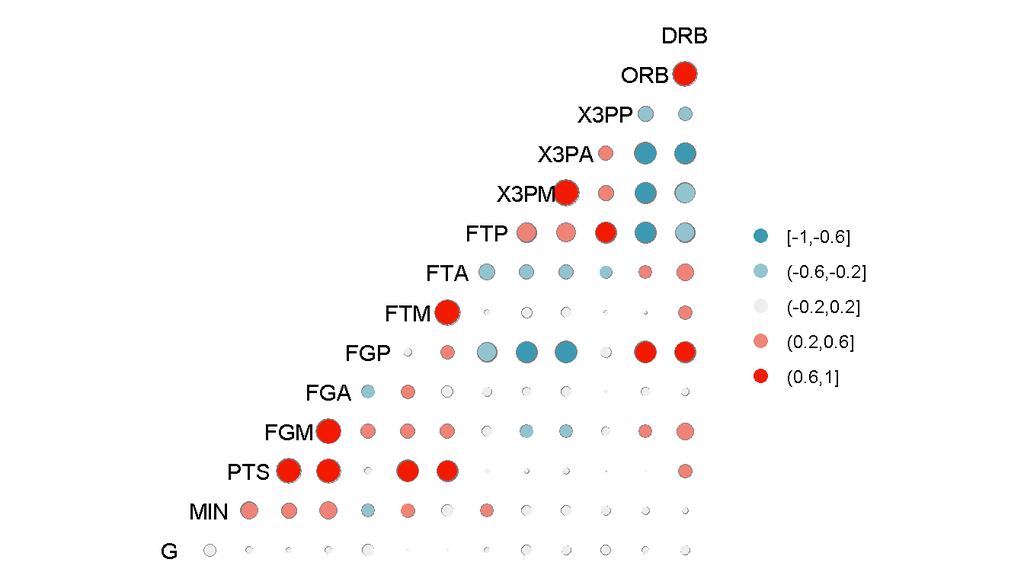

```r
  # ajuste no tamanho dos círculos
ggcorr(nba[, 1:14], geom = "circle", nbreaks = 5, min_size = 0, max_size = 6)
```

#### Controle dos rótulos dos coeficientes:

A função `ggcorr()` pode mostrar os coeficientes de correlação na parte superior da matriz com o argumento `label = TRUE`:

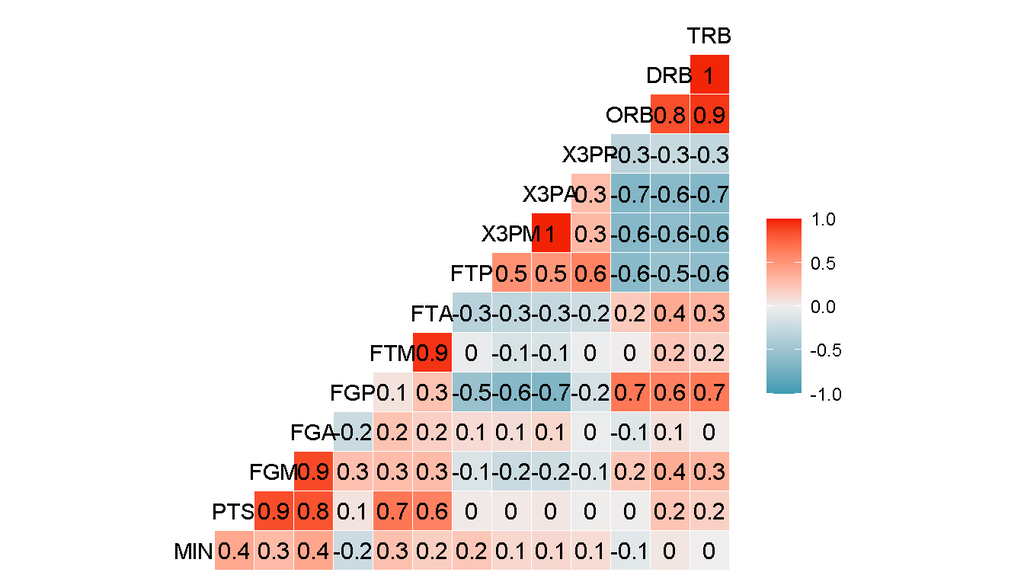

```r
  # ajuste rótulo dos coeficientes
ggcorr(nba[, 2:15], label = TRUE)
```

Os argumentos `label_color` e `label_size` permitem ajustar o estilo dos rótulos dos coeficientes:

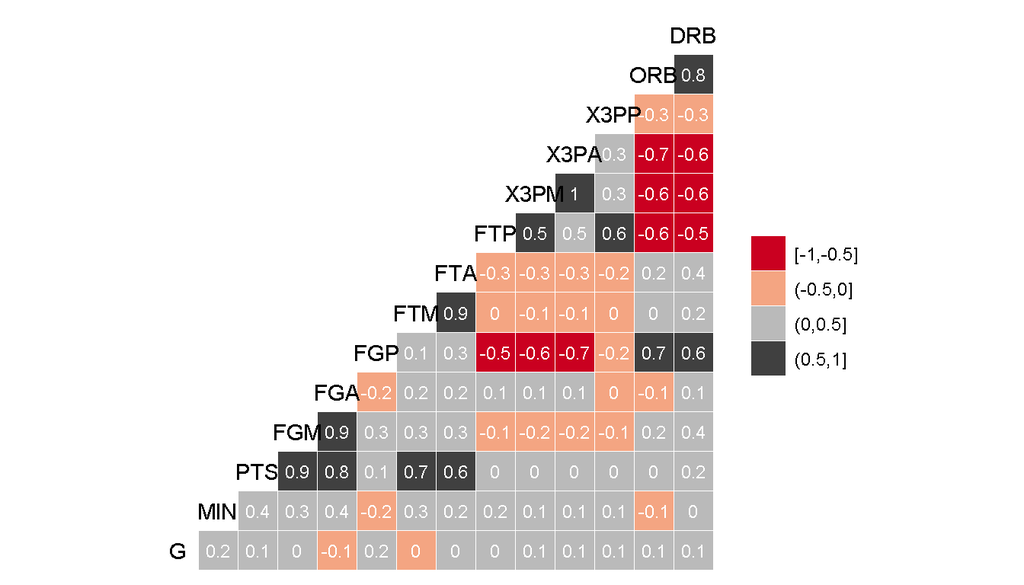

```r
  # estilo rótulos dos coeficientes
ggcorr(nba[, 1:14], nbreaks = 4, palette = "RdGy", label = TRUE,
       label_size = 3, label_color = "white")
```

O argumento `label_round`controla a quantidade de dígitos dos rótulos dos coeficientes, cujo default é um único dígito. Se o argumento `label_alpha` controla o nível de transparência: se `label_alpha = TRUE`, o nível de transpar~encia irá variar da mesma maneira que os coeficientes de correlação, aumentando à medida em que se afasta de 0:

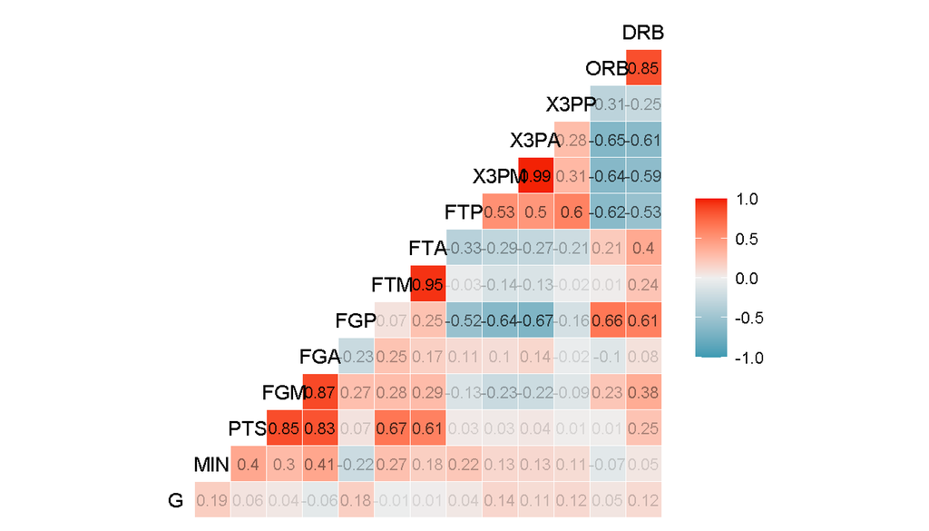

```r
  # nível de transparência
ggcorr(nba[, 1:14], label = TRUE, label_size = 3, label_round = 2,
       label_alpha = TRUE)
```

#### Controle dos rótulos das variáveis:

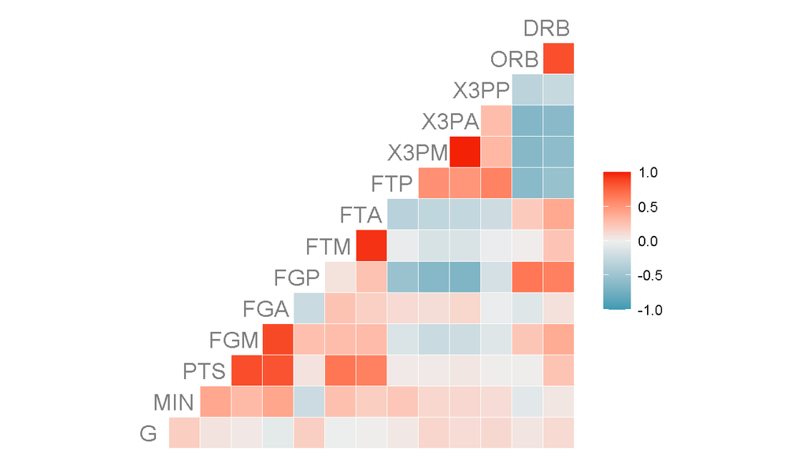

```r
  # rótulo das variáveis
ggcorr(nba[, 1:14], hjust = 0.75, size = 5, color = "grey50")
```

Um provável problema com rótulos de variáveis em uma matriz de correlação é que eles poderão ser muito longos para serem exibidos por completo na parte inferior esquerda do gráfico. Este problema é ilustrado abaixo ao iniciar a matriz de correlação com a variável `MIN`, que parece estar ligeiramente cortada no canto inferior esquerdo do gráfico:

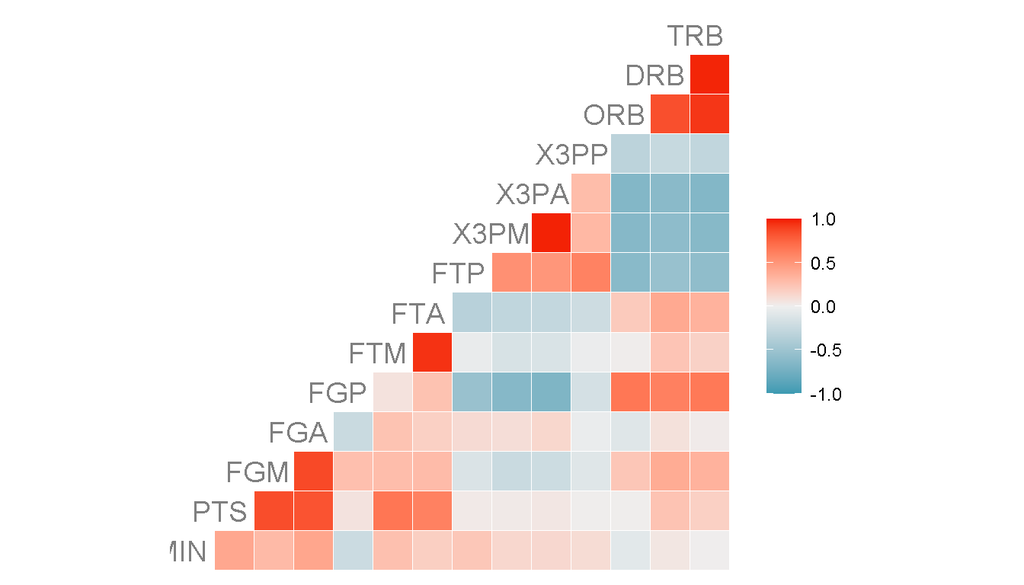

```r
 # nome de variável cortado
ggcorr(nba[, 2:15], hjust = 0.75, size = 5, color = "grey50")
```

Para resolver esse problema, a função `ggcorr` permite acrescentar alguns espaços em branco no eixo horizontal do gráfico por meio do argumento `layout.exp`, acrescentando um ou mais “blocos invisíveis” à esquerda do gráfico, o que pode ajudar na exibição de variáveis com nomes longos:

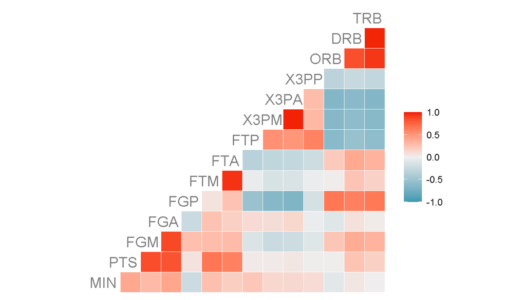

```r
  # ajsutando espaço à esquerda
ggcorr(nba[, 2:15], hjust = 0.75, size = 5, color = "grey50", layout.exp = 1)
```

#### Recortando a escala das correlações:

Pode-se mostrar o intervalo empírico dos coeficientes de correlação em vez do intervalo exato (-1, + 1) na escala de cores. Quando a escala de cores é um gradiente de cores contínuo, isso pode ser obtido definindo o argumento `limits = FALSO`:

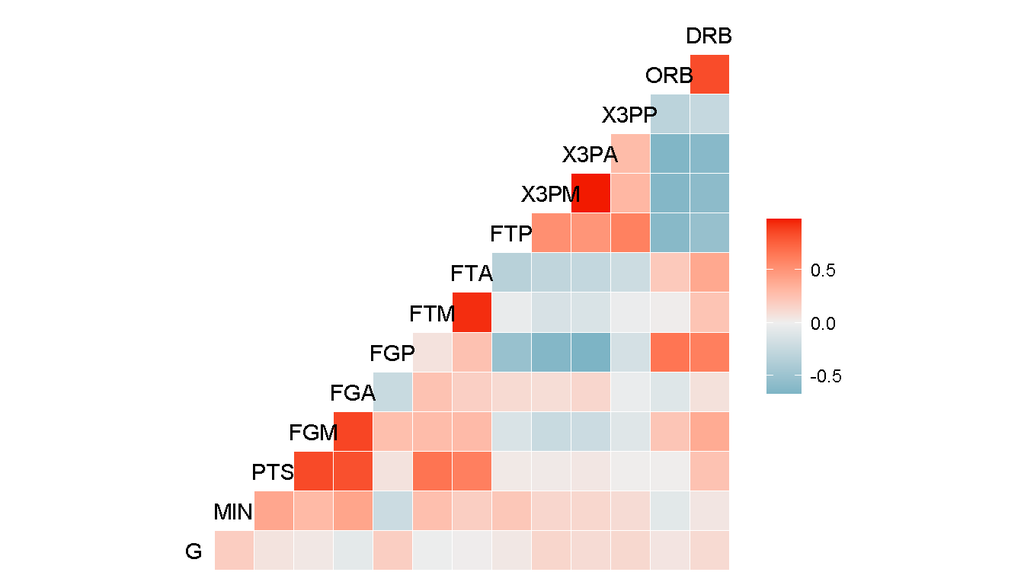

```r
  # mudança escala das correlações
ggcorr(nba[, 1:14], limits = FALSE)
```

Quando a escala de cores é categórica, serão eliminadas os intervalos que não correspondem a nenhum dos coeficientes de correlação, quando ajusta-se o argumento `limits = FALSE` ou, de forma equivalente, `drop = TRUE`:

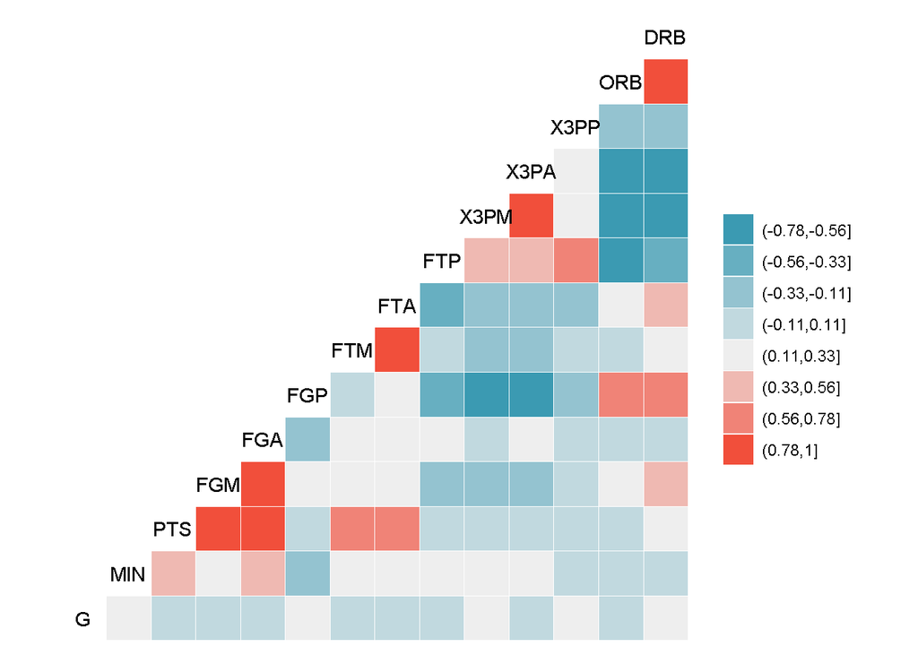

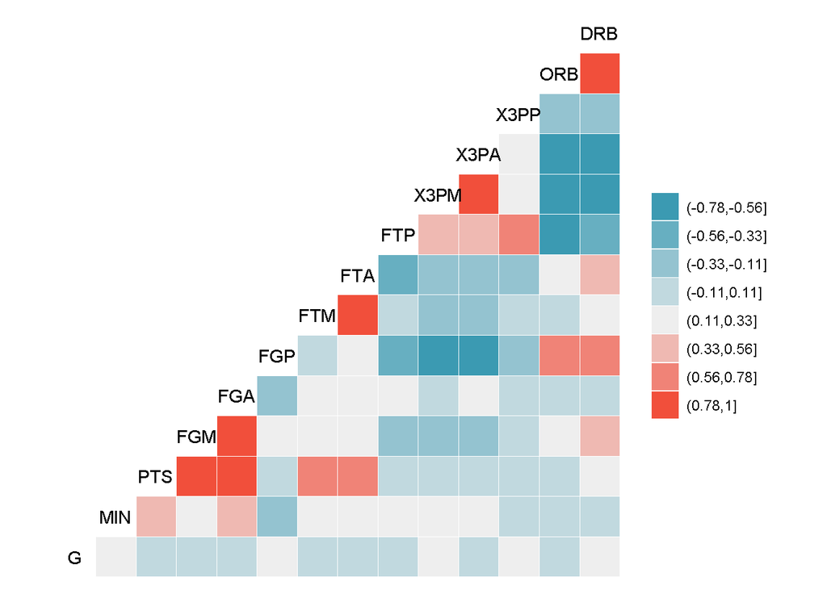

```r
ggcorr(nba[, 1:14], nbreaks = 9, limits = FALSE)
ggcorr(nba[, 1:14], nbreaks = 9,  drop = TRUE)
```

#### Mudando o estilo dos coeficientes de correlação:

Se `geom = "text"`, a função `ggcorr()` apresentará os coeficientes de correlação com seu valores coloridos:

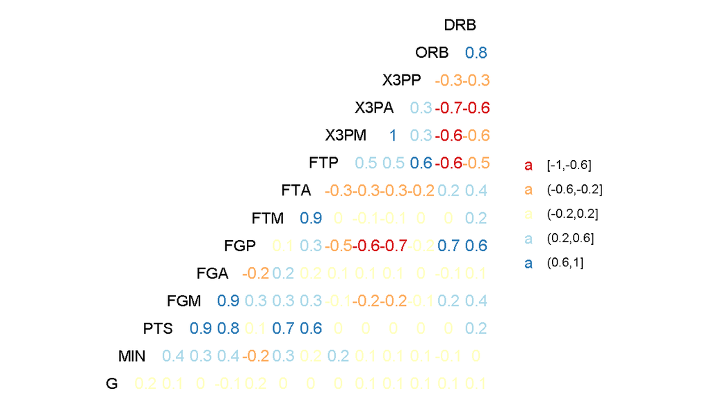

```r
  # mudança de estilo dos coeficientes de correlação
ggcorr(nba[, 1:14], geom = "text", nbreaks = 5, palette = "RdYlBu",
       hjust = 1)
```

O tamanho desses valors será ajustado para o tamanho especificado no argumento `label_size`, permitindo controlar os rótulos dos coeficientes:

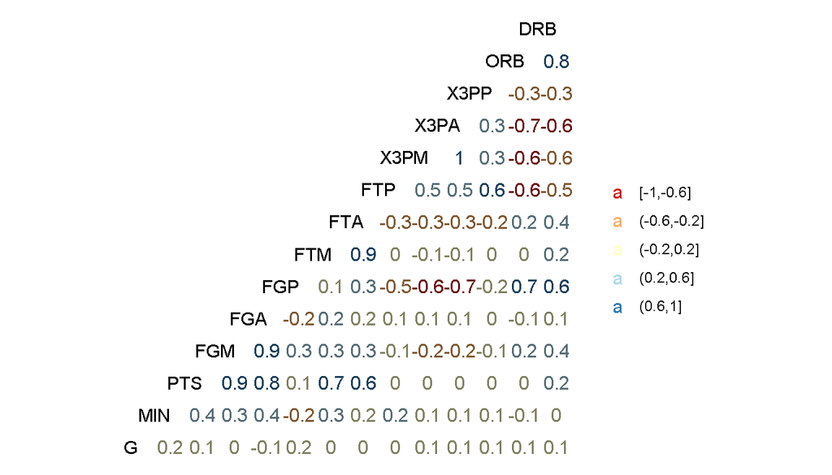

```r
  # controle dos rótulos dos coeficientes
ggcorr(nba[, 1:14], geom = "text", nbreaks = 5, palette = "RdYlBu",
       hjust = 1, label = TRUE, label_alpha = 0.5)
```

Por outro lado, se ajusta-se `geom = "blank"`, nada será plotado, que pode ser útil para controlar os valores internos do gráfico.

#### Controlando os valores internos do gráfico:

a função `ggcorr()` produz objetos gráficos (*grobs*) `ggplot2`. Para obter plots mais específicos desses objetos, convém compreendermos como esse obejto é construído. Todo objeto `ggcorr` contém os seguintes dados:

```r
head(ggcorr(nba[, 1:14])$data, 5)
```

```
##     x y coefficient label
## 2 MIN G  0.18686608   0.2
## 3 PTS G  0.06309908   0.1
## 4 FGM G  0.03992195   0.0
## 5 FGA G -0.05958051  -0.1
## 6 FGP G  0.18087541   0.2
```

Isso permite ter um certo grau de controle aos valores internos de `ggcorr`. Por exemplo, realçar os coeficientes de correlação superiores a 0,5 e inferiores a -0,5, usando diferentes cores para os coeficientes positivos e negativos.

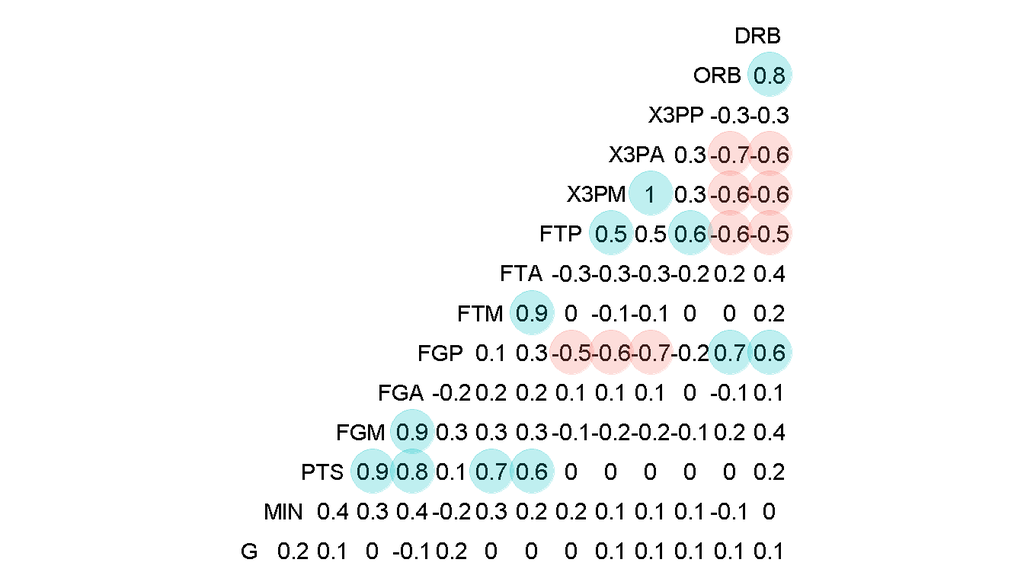

```r
ggcorr(nba[, 1:14], geom = "blank", label = TRUE, hjust = 0.75) +
  geom_point(size = 10, aes(color = coefficient > 0,
                            alpha = abs(coefficient) > 0.5)) +
  scale_alpha_manual(values = c("TRUE" = 0.25, "FALSE" = 0)) +
  guides(color = FALSE, alpha = FALSE)
```

#### Limitações:

a função `ggcorr()` é limitada exclusivamente a matrizes de correlação, não podendo construir mapas de calor (*heatmaps*) ou mapas de calor de agrupamentos (*cluster heatmaps*). Esse pode ser plotado com `ggplot2`, por meio do pacote `gapmap`.

### Correlograma com o pacote `corrplot`:

O pacote `corrplot` temos mais funcionalidades gráficas e detalhes para apresentar as correlações, como por exemplo 7 tipos de visualização gráfica: círculos, quadrados, elipses, números, sombras, cores e gráficos de pizza`“circle”`, `“square”`, `“ellipse”`, `“number”`, `“shade”`, `“color”`, `“pie”`.

```r
library(corrplot)
```

## Referências

ggcorr: correlation matrixes with ggplot2 https://briatte.github.io/ggcorr/